# Instructions

1. If there is a conflict bewteen the problem description in the ipython notebook and the question in the pdf, follow the question in the pdf file.
2. The part you need to fill in is commented as "Code Clip". You can search "Code Clip" in this notebook to find the part you need to complete. After you finish the required part, you may need to run other related code blocks for evaluation or visualization.
3. If you have a better implementation or find mistakes in this notebook, you could add/modify any function (input, output and return) yourself. Everything is flexible as long as you answered the questions.

```python
import pandas as pd
import numpy as np
import matplotlib.pyplot as plt
import seaborn as sns
```

```python
from sklearn.model_selection import train_test_split, cross_val_score, KFold
from sklearn.metrics import accuracy_score, auc,roc_curve
from sklearn import preprocessing
from sklearn import metrics
from scipy.stats import ttest_ind
import timeit
```

### Load Training and Testing Data. Get a initial statistics of the training data.

```python
train_data = pd.read_csv('./data_train.csv')
test_data = pd.read_csv('./data_test.csv')
```

```python
features_mean = list(train_data.columns[1:31])


X_train = train_data.loc[:,features_mean]
y_train = train_data.loc[:, 'diagnosis']

X_test = test_data.loc[:,features_mean]
y_test = test_data.loc[:, 'diagnosis']
```

# 3.1 Balanced Dataset

### 3.1.1 Use 5-fold cross validation on the training set only, and compare accuracy and time cost performance of three different algorithms: ID3, CART and Random Forest,

Code Clip 3.1.1a: Complete the function `compare`.

```python
from sklearn.metrics import confusion_matrix
def accuracy_all(predict, label):
    cm = confusion_matrix(label, predict)
    return np.sum(np.diag(cm))/np.sum(np.sum(cm))
```

```python
from sklearn.ensemble import RandomForestClassifier
from sklearn.ensemble import ExtraTreesClassifier
from sklearn.tree import DecisionTreeClassifier
from sklearn.model_selection import KFold

def compare_algorithms(X_train, y_train):
    score = pd.DataFrame()
    accuracy = pd.DataFrame()
    time_cost = pd.DataFrame()
    stats = pd.DataFrame()
    t_stats = pd.DataFrame()
    X_train_cross = pd.DataFrame()
    X_test_cross = pd.DataFrame()
    y_train_cross = pd.DataFrame()
    y_test_cross = pd.DataFrame()

    kf = KFold(n_splits=5)
    kf.get_n_splits(X_train)

    i = 0
    for train_index, test_index in kf.split(X_train):
        # print("TRAIN:", train_index, "TEST:", test_index)

        X_train_cross, X_test_cross = X_train.loc[train_index], X_train.loc[test_index]
        y_train_cross, y_test_cross = y_train.loc[train_index], y_train.loc[test_index]


        start = timeit.default_timer()
        clf_ID3 = DecisionTreeClassifier(criterion="entropy")
        clf_ID3 = clf_ID3.fit(X_train_cross,y_train_cross)
        score.at[i,'ID3'] = clf_ID3.score(X_test_cross,y_test_cross)
        y_predict = clf_ID3.predict(X_test_cross)
        accuracy.at[i,'ID3'] = accuracy_all(y_predict, y_test_cross)
        stop = timeit.default_timer()
        time_cost.at[i,'ID3'] = stop - start


        start = timeit.default_timer()
        clf_CART = DecisionTreeClassifier(criterion="gini")
        clf_CART = clf_CART.fit(X_train_cross,y_train_cross)
        score.at[i,'CART'] = clf_CART.score(X_test_cross,y_test_cross)
        y_predict = clf_CART.predict(X_test_cross)
        accuracy.at[i,'CART'] = accuracy_all(y_predict, y_test_cross)
        stop = timeit.default_timer()
        stop = timeit.default_timer()
        time_cost.at[i,'CART'] = stop - start



        start = timeit.default_timer()
        clf_RF =  RandomForestClassifier(n_estimators = 50, criterion="gini")
        clf_RF = clf_RF.fit(X_train_cross,y_train_cross)
        score.at[i,'RF'] = clf_RF.score(X_test_cross,y_test_cross)
        y_predict = clf_RF.predict(X_test_cross)
        accuracy.at[i,'RF'] = accuracy_all(y_predict, y_test_cross)
        stop = timeit.default_timer()
        stop = timeit.default_timer()
        time_cost.at[i,'RF'] = stop - start

        i = i+1

    stats["Means"] = accuracy.mean()
    stats["Standard Deviations"] = accuracy.std()

    a = accuracy['ID3'].to_numpy()
    b = accuracy['CART'].to_numpy()
    t_stats.at['ID3 & CART','ttest'], t_stats.at['ID3 & CART','p-value']= ttest_ind(a,b)

    b = accuracy['ID3'].to_numpy()
    a = accuracy['RF'].to_numpy()
    t_stats.at['ID3 & RF','ttest'], t_stats.at['ID3 & RF','p-value']=ttest_ind(a,b)

    b = accuracy['CART'].to_numpy()
    a = accuracy['RF'].to_numpy()
    t_stats.at['CART & RF','ttest'], t_stats.at['CART & RF','p-value'] =ttest_ind(a,b)

    return stats, t_stats, score, accuracy, time_cost
```

```python
stats, t_stats, score, accuracy, time_cost = compare_algorithms(X_train, y_train)
```

```python
stats
```

|  | Means | Standard Deviations |
| --- | --- | --- |
| ID3 | 0.949451 | 0.022787 |
| CART | 0.929670 | 0.016666 |
| RF | 0.953846 | 0.016299 |

```python
t_stats
```

|  | ttest | p-value |
| --- | --- | --- |
| ID3 & CART | 1.566699 | 0.155819 |
| ID3 & RF | 0.350823 | 0.734780 |
| CART & RF | 2.319004 | 0.048996 |

The average accuracy for ID3 is 0.95, for CART is 0.93, and for Random Forest is 0.95. The standard deviations of accuracy for ID3 is 0.02, for CART is 0.02, and for Random Forest is 0.02. The t-test shows that, if the threshold is 0.1, the random forest algorithm is significantly better than CART algorithm; the different between random forest and ID3 is not singificant under this critiria.

```python
score
```

|  | ID3 | CART | RF |
| --- | --- | --- | --- |
| 0 | 0.967033 | 0.912088 | 0.978022 |
| 1 | 0.945055 | 0.934066 | 0.934066 |
| 2 | 0.934066 | 0.923077 | 0.956044 |
| 3 | 0.978022 | 0.956044 | 0.956044 |
| 4 | 0.923077 | 0.923077 | 0.945055 |

```python
accuracy
```

|  | ID3 | CART | RF |
| --- | --- | --- | --- |
| 0 | 0.967033 | 0.912088 | 0.978022 |
| 1 | 0.945055 | 0.934066 | 0.934066 |
| 2 | 0.934066 | 0.923077 | 0.956044 |
| 3 | 0.978022 | 0.956044 | 0.956044 |
| 4 | 0.923077 | 0.923077 | 0.945055 |

```python
time_cost
```

|  | ID3 | CART | RF |
| --- | --- | --- | --- |
| 0 | 0.010895 | 0.008172 | 0.083852 |
| 1 | 0.008787 | 0.005738 | 0.077919 |
| 2 | 0.007826 | 0.005241 | 0.082055 |
| 3 | 0.007494 | 0.007380 | 0.077848 |
| 4 | 0.007404 | 0.006787 | 0.081429 |

### 3.1.2 Effect of the depth.

Code Clip 3.1.2: Complete the function `run_cross_validation_on_trees`.

```python
def run_cross_validation_on_trees(X, y, tree_depths, cv=5, scoring='accuracy'):
    cv_scores_list = []
    cv_scores_std = []
    cv_scores_mean = []
    accuracy_scores = []

    accuracy = pd.DataFrame()
    stats = pd.DataFrame()

    for depth in tree_depths:
        # Get the accuracy, mean, std from the cross validation.
        kf = KFold(n_splits=5)
        i = 0
        for train_index, test_index in kf.split(X_train):
        # print("TRAIN:", train_index, "TEST:", test_index)

            X_train_cross, X_test_cross = X_train.loc[train_index], X_train.loc[test_index]
            y_train_cross, y_test_cross = y_train.loc[train_index], y_train.loc[test_index]

            clf_RF =  RandomForestClassifier(max_depth = depth)
            clf_RF = clf_RF.fit(X_train_cross,y_train_cross)
            accuracy.at[i,depth] = clf_RF.score(X_test_cross,y_test_cross)
            i = i+1

    cv_scores_mean = accuracy.mean()
    cv_scores_std = accuracy.std()

    best_depth = cv_scores_mean.idxmax()

    clf_RF =  RandomForestClassifier(max_depth = depth)
    clf_RF = clf_RF.fit(X_train,y_train)
    accuracy_best = clf_RF.score(X_test,y_test)

    # print(best_depth,accuracy_best)

    cv_scores_mean = np.array(cv_scores_mean)
    cv_scores_std = np.array(cv_scores_std)
    # print(cv_scores_std)
    # print(cv_scores_mean)


    return cv_scores_mean, cv_scores_std, accuracy_scores, best_depth, accuracy_best






# function for plotting cross-validation results
def plot_cross_validation_on_trees(depths, cv_scores_mean, cv_scores_std, accuracy_scores, title):
    fig, ax = plt.subplots(1,1, figsize=(15,5))
    ax.plot(depths, cv_scores_mean, '-o', label='mean cross-validation accuracy', alpha=0.9)
    ax.fill_between(depths, cv_scores_mean-2*cv_scores_std, cv_scores_mean+2*cv_scores_std, alpha=0.2)
    ylim = plt.ylim()
    # ax.plot(depths, accuracy_scores, '-*', label='train accuracy', alpha=0.9)
    ax.set_title(title, fontsize=16)
    ax.set_xlabel('Tree depth', fontsize=14)
    ax.set_ylabel('Accuracy', fontsize=14)
    ax.set_ylim([0.8,1])
    ax.set_xticks(depths)
    ax.legend()
```

```
The best depth:  7
The accuracy with the best depth:  0.9649122807017544
```

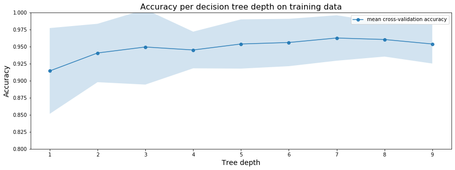

```python
sm_tree_depths = range(1,10)
sm_cv_scores_mean, sm_cv_scores_std, sm_accuracy_scores, best_depth, accuracy_best = run_cross_validation_on_trees(X_train, y_train, sm_tree_depths)

print("The best depth: ", best_depth)
print("The accuracy with the best depth: ", accuracy_best)

# plotting accuracy
plot_cross_validation_on_trees(sm_tree_depths, sm_cv_scores_mean, sm_cv_scores_std, sm_accuracy_scores,
                               'Accuracy per decision tree depth on training data')
plt.show()

# Play: Only uses the first ten features.
# sm_cv_scores_mean2, sm_cv_scores_std2, sm_accuracy_scores2 = run_cross_validation_on_trees(X_train.iloc[:,:10],
#                                                                                         y_train, sm_tree_depths)

# # plotting accuracy
# plot_cross_validation_on_trees(sm_tree_depths, sm_cv_scores_mean2, sm_cv_scores_std2, sm_accuracy_scores2,
#                                'Accuracy per decision tree depth on training data')
# plt.show()
```

### 3.1.3 ROC and vairable importance

Code Clip 3.1.3a: Complete the function `draw_roc_with_feature_idx`. Then finished the next two steps (`AUC of different features` and `Draw ROC Curve of the first five features`.

```python
import random

def plot_roc(fpr, tpr, roc_auc, title = ''):
    plt.figure()
    lw = 2
    plt.plot(fpr, tpr, color='darkorange',
             lw=lw, label='ROC curve (area ={})'.format(roc_auc))
    plt.plot([0, 1], [0, 1], color='navy', lw=lw, linestyle='--')
    plt.xlim([0.0, 1.0])
    plt.ylim([0.0, 1.05])
    plt.xlabel('False Positive Rate')
    plt.ylabel('True Positive Rate')
    plt.title('Receiver operating characteristic over {}'.format(title))
    plt.legend(loc="lower right")
    plt.show()

def plot_roc_multi(fpr, tpr, roc_auc, title = ''):
    plt.figure()
    lw = 2
    for k in range(6):
        for i in range(k*5,k*5+5):
            r = random.random()
            b = random.random()
            g = random.random()
            color_temp = (r, g, b)
            plt.plot(fpr[i], tpr[i], color=color_temp,
                 lw=lw, label='{} ROC curve (area ={})'.format(X_test.columns[i],roc_auc.at[1,i]))
        plt.plot([0, 1], [0, 1], color='navy', lw=lw, linestyle='--')
        plt.xlim([0.0, 1.0])
        plt.ylim([0.0, 1.05])
        plt.xlabel('False Positive Rate')
        plt.ylabel('True Positive Rate')
        plt.title('Receiver operating characteristic over {}'.format(title))
        plt.legend(bbox_to_anchor=(1.04,1), loc="upper left")
        plt.show()


    for i in range(30):
        r = random.random()
        b = random.random()
        g = random.random()
        color_temp = (r, g, b)
        plt.plot(fpr[i], tpr[i], color=color_temp,
             lw=lw, label='{} ROC curve (area ={})'.format(X_test.columns[i],roc_auc.at[1,i]))
    plt.plot([0, 1], [0, 1], color='navy', lw=lw, linestyle='--')
    plt.xlim([0.0, 1.0])
    plt.ylim([0.0, 1.05])
    plt.xlabel('False Positive Rate')
    plt.ylabel('True Positive Rate')
    plt.title('Receiver operating characteristic over {}'.format(title))
    plt.legend(bbox_to_anchor=(1.04,1), loc="upper left")
    plt.show()


def draw_roc_with_feature_idx(X_test, y_test, i, draw = False):

    # Code Clip 3.1.3
    # calculate list of false positive rate and true positive rate.
    # calculate AUC.

    TPR = []
    FPR = []
    ROC = []
    AUC = []
    X_columns = list(X_test.columns)
    max_value = X_test[X_columns[i]].max()
    min_value = X_test[X_columns[i]].min()
    for j in np.arange(min_value-0.000001, max_value+0.000001, (max_value-min_value)/1000):
        TPR_temp = 0
        FPR_temp = 0
        num_Pos = 0
        num_Neg = 0
        for k in range(0,len(X_test.index)):
            if X_test.at[k, X_columns[i]] > j and y_test[k] == 1:
                    TPR_temp = TPR_temp + 1
            if X_test.at[k, X_columns[i]] > j and y_test[k] == 0:
                    FPR_temp = FPR_temp + 1
        for k in range(0,len(X_test.index)):
            if y_test[k] == 1:
                num_Pos = num_Pos + 1
            if y_test[k] == 0:
                num_Neg = num_Neg + 1

        TPR_temp = TPR_temp / num_Pos
        FPR_temp = FPR_temp / num_Neg

        TPR.append(TPR_temp)
        FPR.append(FPR_temp)

    ROC_AUC = metrics.auc(FPR, TPR)

    if draw:
        plot_roc(FPR, TPR, ROC_AUC, title = 'Feature' + str(i))

    return ROC_AUC, TPR, FPR
```

```python
TPR_temp = pd.DataFrame()
FPR_temp = pd.DataFrame()
TPR_all = pd.DataFrame()
FPR_all = pd.DataFrame()
auc_all = pd.DataFrame()
for i in range(30):
    print(i, end = ' ')
    auc_temp, TPR_temp, FPR_temp = draw_roc_with_feature_idx(X_test, y_test, i, draw = False)
    TPR_all.at[:,i] = TPR_temp
    FPR_all.at[:,i] = FPR_temp
    auc_all.at[1,i] = auc_temp
```

```
0 1 2 3 4 5 6 7 8 9 10 11 12 13 14 15 16 17 18 19 20 21 22 23 24 25 26 27 28 29
```

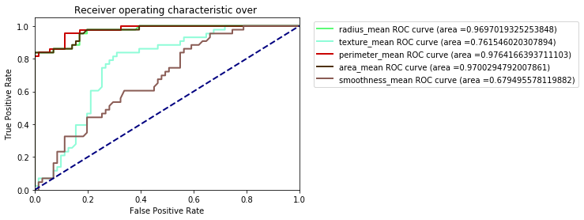

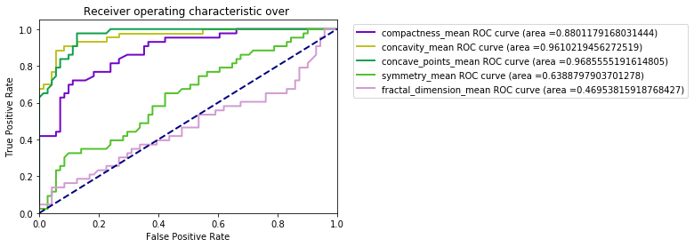

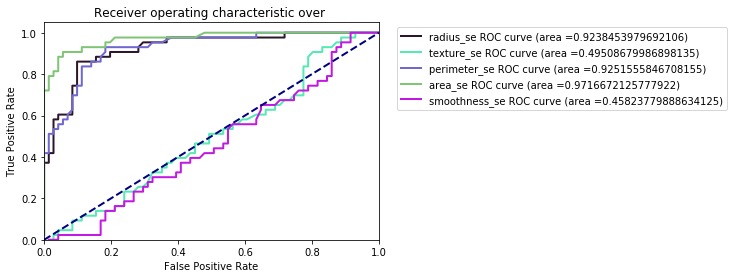

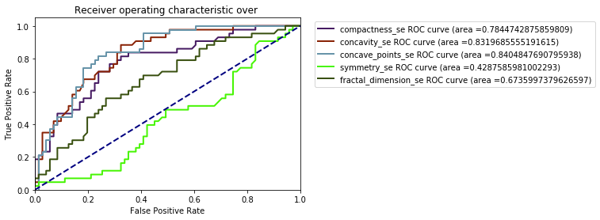

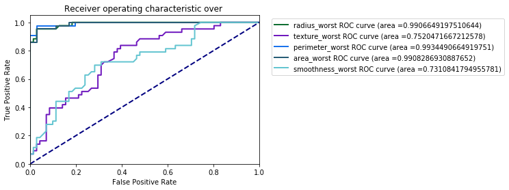

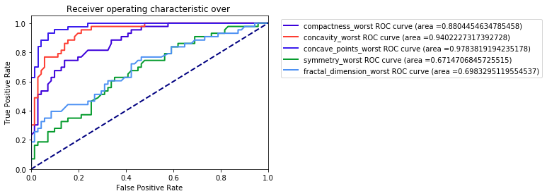

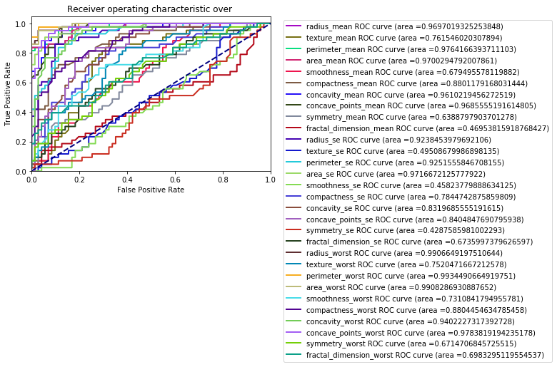

```python
plot_roc_multi(FPR_all,TPR_all, auc_all, title = '')
```

### AUC of different features

Code clip 3.1.3b, You may find plt.bar useful here.

```
No handles with labels found to put in legend.
```

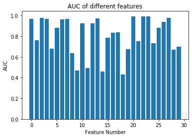

```python
plt.figure()

# Code Clip 3.1.3b

auc_draw = []
for i in range(30):
    auc_draw.append(auc_all.at[1,i])
plt.bar(range(X_test.shape[1]), auc_draw)
plt.xlabel('Feature Number')
plt.ylabel('AUC')
plt.title('AUC of different features')
plt.legend(loc="lower right")
plt.show()
```

```python
# I report the important features with AUC > 0.8
for i in range(30):
    if auc_all.at[1,i] > 0.8:
        print(X_test.columns[i])
```

```
radius_mean
perimeter_mean
area_mean
compactness_mean
concavity_mean
concave_points_mean
radius_se
perimeter_se
area_se
concavity_se
concave_points_se
radius_worst
perimeter_worst
area_worst
compactness_worst
concavity_worst
concave_points_worst
```

```python
# I also report the rank of importance of features (from important to less imprtant)

X_test.columns[np.argsort(auc_draw)[::-1]]
```

```
Index(['perimeter_worst', 'area_worst', 'radius_worst', 'concave_points_worst',
       'perimeter_mean', 'area_se', 'area_mean', 'radius_mean',
       'concave_points_mean', 'concavity_mean', 'concavity_worst',
       'perimeter_se', 'radius_se', 'compactness_worst', 'compactness_mean',
       'concave_points_se', 'concavity_se', 'compactness_se', 'texture_mean',
       'texture_worst', 'smoothness_worst', 'fractal_dimension_worst',
       'smoothness_mean', 'fractal_dimension_se', 'symmetry_worst',
       'symmetry_mean', 'texture_se', 'fractal_dimension_mean',
       'smoothness_se', 'symmetry_se'],
      dtype='object')
```

### 3.1.4 Partial ROC

Code Clip 3.1.4 Follow the intruction in the question. You could test the correctness of your code by setting $t_0 = 0, t_1= 1$.

```python
# Code Clip 3.1.4
t0 = 0
t1 = 0.2
TPR_work = []
NPR_work = []
for i in range(5):
    TPR_work  = TPR_all.iloc[:][i]
    FPR_work  = FPR_all.iloc[:][i]
    # delete all values out of the range(t0,t1)
    for j in range(0, len(TPR_work.index)):
        if FPR_work[j] > t1 or FPR_work[j] < t0:
            FPR_work[j] = -1
            TPR_work[j] = -1
    TPR_work = [x for x in TPR_work if x != -1]
    FPR_work = [x for x in FPR_work if x != -1]
    Partial_AUC = metrics.auc(FPR_work, TPR_work)
    Partial_AUC = Partial_AUC/(t1-t0)
    print(Partial_AUC)
```

```
0.8565345561742546
0.19079593842122503
0.8827382902063543
0.8589911562397641
0.20062233868326237
```

### 3.1.5 Model Reliance of CART model

Code Clip 3.1.5 Follow the instruction in the question.

```python
feature = 'radius_mean'
train_data = pd.read_csv('./data_train.csv')
test_data = pd.read_csv('./data_test.csv')

X_train = train_data.loc[:,features_mean]
y_train = train_data.loc[:, 'diagnosis']

X_test = test_data.loc[:,features_mean]
y_test = test_data.loc[:, 'diagnosis']

X_scramble = np.random.permutation(X_train[feature].values)
for i in range(0, len(X_scramble)):
    X_train.at[i,feature] = X_scramble[i]
```

```python
# Code Clip 3.1.5


pd.options.display.max_columns = 100

train_data = pd.read_csv('./data_train.csv')
test_data = pd.read_csv('./data_test.csv')

X_train = train_data.loc[:,features_mean]
y_train = train_data.loc[:, 'diagnosis']

X_test = test_data.loc[:,features_mean]
y_test = test_data.loc[:, 'diagnosis']

X = np.concatenate([X_train, X_test], axis= 0)
y = np.concatenate([y_train, y_test], axis= 0)

accuracy_reliance = pd.DataFrame()
clf_CART = DecisionTreeClassifier(criterion="gini")
clf_CART = clf_CART.fit(X_train,y_train)
accuracy_origin_test =  clf_CART.score(X_test,y_test)
accuracy_origin_entire = clf_CART.score(X,y)

for feature in features_mean:
    train_data = pd.read_csv('./data_train.csv')
    test_data = pd.read_csv('./data_test.csv')

    X_train = train_data.loc[:,features_mean]
    y_train = train_data.loc[:, 'diagnosis']

    X_test = test_data.loc[:,features_mean]
    y_test = test_data.loc[:, 'diagnosis']

    X_scramble = np.random.permutation(X_train[feature].values)
    for i in range(0, len(X_scramble)):
        X_train.at[i,feature] = X_scramble[i]

    clf_CART = DecisionTreeClassifier(criterion="gini")
    clf_CART = clf_CART.fit(X_train,y_train)
    accuracy_reliance.at['score_testset',feature] = clf_CART.score(X_test,y_test)
    # accuracy_reliance.at['loss_increase',feature] = accuracy_origin - accuracy_reliance.at['score',feature]


    # I would like to calculate the score over the entire dataset as well
    train_data = pd.read_csv('./data_train.csv')
    test_data = pd.read_csv('./data_test.csv')

    X_train = train_data.loc[:,features_mean]
    y_train = train_data.loc[:, 'diagnosis']

    X_test = test_data.loc[:,features_mean]
    y_test = test_data.loc[:, 'diagnosis']

    X = np.concatenate([X_train, X_test], axis= 0)
    y = np.concatenate([y_train, y_test], axis= 0)

    accuracy_reliance.at['score_entireset',feature] = clf_CART.score(X,y)

    accuracy_reliance.at['loss_increase_testset',feature] = accuracy_origin_test - accuracy_reliance.at['score_testset',feature]
    accuracy_reliance.at['loss_increase_entireset',feature] = accuracy_origin_entire - accuracy_reliance.at['score_entireset',feature]

accuracy_reliance
```

|  | radius_mean | texture_mean | perimeter_mean | area_mean | smoothness_mean | compactness_mean | concavity_mean | concave_points_mean | symmetry_mean | fractal_dimension_mean | radius_se | texture_se | perimeter_se | area_se | smoothness_se | compactness_se | concavity_se | concave_points_se | symmetry_se | fractal_dimension_se | radius_worst | texture_worst | perimeter_worst | area_worst | smoothness_worst | compactness_worst | concavity_worst | concave_points_worst | symmetry_worst | … |
| --- | --- | --- | --- | --- | --- | --- | --- | --- | --- | --- | --- | --- | --- | --- | --- | --- | --- | --- | --- | --- | --- | --- | --- | --- | --- | --- | --- | --- | --- | --- |
| score_testset | 0.921053 | 0.938596 | 0.938596 | 0.938596 | 0.947368 | 0.947368 | 0.938596 | 0.947368 | 0.947368 | 0.938596 | 0.929825 | 0.929825 | 0.938596 | 0.929825 | 0.938596 | 0.929825 | 0.921053 | 0.929825 | 0.938596 | 0.947368 | 0.938596 | 0.938596 | 0.929825 | 0.929825 | 0.938596 | 0.938596 | 0.947368 | 0.964912 | 0.929825 | … |
| score_entireset | 0.984183 | 0.985940 | 0.985940 | 0.987698 | 0.989455 | 0.968366 | 0.984183 | 0.978910 | 0.989455 | 0.987698 | 0.985940 | 0.985940 | 0.987698 | 0.984183 | 0.980668 | 0.985940 | 0.975395 | 0.985940 | 0.987698 | 0.989455 | 0.987698 | 0.987698 | 0.985940 | 0.985940 | 0.987698 | 0.987698 | 0.989455 | 0.992970 | 0.985940 | … |
| loss_increase_testset | 0.017544 | 0.000000 | 0.000000 | 0.000000 | -0.008772 | -0.008772 | 0.000000 | -0.008772 | -0.008772 | 0.000000 | 0.008772 | 0.008772 | 0.000000 | 0.008772 | 0.000000 | 0.008772 | 0.017544 | 0.008772 | 0.000000 | -0.008772 | 0.000000 | 0.000000 | 0.008772 | 0.008772 | 0.000000 | 0.000000 | -0.008772 | -0.026316 | 0.008772 | … |
| loss_increase_entireset | 0.003515 | 0.001757 | 0.001757 | 0.000000 | -0.001757 | 0.019332 | 0.003515 | 0.008787 | -0.001757 | 0.000000 | 0.001757 | 0.001757 | 0.000000 | 0.003515 | 0.007030 | 0.001757 | 0.012302 | 0.001757 | 0.000000 | -0.001757 | 0.000000 | 0.000000 | 0.001757 | 0.001757 | 0.000000 | 0.000000 | -0.001757 | -0.005272 | 0.001757 | … |

```python
# for better output
accuracy_reliance_transposed = accuracy_reliance.T
accuracy_reliance_transposed
```

|  | score_testset | score_entireset | loss_increase_testset | loss_increase_entireset |
| --- | --- | --- | --- | --- |
| radius_mean | 0.921053 | 0.984183 | 0.017544 | 0.003515 |
| texture_mean | 0.938596 | 0.985940 | 0.000000 | 0.001757 |
| perimeter_mean | 0.938596 | 0.985940 | 0.000000 | 0.001757 |
| area_mean | 0.938596 | 0.987698 | 0.000000 | 0.000000 |
| smoothness_mean | 0.947368 | 0.989455 | -0.008772 | -0.001757 |
| compactness_mean | 0.947368 | 0.968366 | -0.008772 | 0.019332 |
| concavity_mean | 0.938596 | 0.984183 | 0.000000 | 0.003515 |
| concave_points_mean | 0.947368 | 0.978910 | -0.008772 | 0.008787 |
| symmetry_mean | 0.947368 | 0.989455 | -0.008772 | -0.001757 |
| fractal_dimension_mean | 0.938596 | 0.987698 | 0.000000 | 0.000000 |
| radius_se | 0.929825 | 0.985940 | 0.008772 | 0.001757 |
| texture_se | 0.929825 | 0.985940 | 0.008772 | 0.001757 |
| perimeter_se | 0.938596 | 0.987698 | 0.000000 | 0.000000 |
| area_se | 0.929825 | 0.984183 | 0.008772 | 0.003515 |
| smoothness_se | 0.938596 | 0.980668 | 0.000000 | 0.007030 |
| compactness_se | 0.929825 | 0.985940 | 0.008772 | 0.001757 |
| concavity_se | 0.921053 | 0.975395 | 0.017544 | 0.012302 |
| concave_points_se | 0.929825 | 0.985940 | 0.008772 | 0.001757 |
| symmetry_se | 0.938596 | 0.987698 | 0.000000 | 0.000000 |
| fractal_dimension_se | 0.947368 | 0.989455 | -0.008772 | -0.001757 |
| radius_worst | 0.938596 | 0.987698 | 0.000000 | 0.000000 |
| texture_worst | 0.938596 | 0.987698 | 0.000000 | 0.000000 |
| perimeter_worst | 0.929825 | 0.985940 | 0.008772 | 0.001757 |
| area_worst | 0.929825 | 0.985940 | 0.008772 | 0.001757 |
| smoothness_worst | 0.938596 | 0.987698 | 0.000000 | 0.000000 |
| compactness_worst | 0.938596 | 0.987698 | 0.000000 | 0.000000 |
| concavity_worst | 0.947368 | 0.989455 | -0.008772 | -0.001757 |
| concave_points_worst | 0.964912 | 0.992970 | -0.026316 | -0.005272 |
| symmetry_worst | 0.929825 | 0.985940 | 0.008772 | 0.001757 |
| fractal_dimension_worst | 0.938596 | 0.987698 | 0.000000 | 0.000000 |

# 3.2 Imbalanced Dataset

### 3.2.1： What is the ratio between the two labels ?

Code Clip 3.2.1

```python
# Code Clip 3.2.1
train_data = pd.read_csv('./data_imbalanced_train.csv')
test_data = pd.read_csv('./data_imbalanced_test.csv')

features_mean = list(train_data.columns[1:31])

X_train = train_data.loc[:,features_mean]
y_train = train_data.loc[:, 'diagnosis']

X_test = test_data.loc[:,features_mean]
y_test = test_data.loc[:, 'diagnosis']

X = np.concatenate([X_train, X_test], axis= 0)
y = np.concatenate([y_train, y_test], axis= 0)

imbalance_ratio = pd.DataFrame()

pos = 0
neg = 0
for i in range(0,len(y_train)):
    if y_train[i] == 0:
        neg = neg + 1
    elif y_train[i] == 1:
        pos = pos + 1
imbalance_ratio.at[1,'training set'] = neg/pos

pos = 0
neg = 0
for i in range(0,len(y_test)):
    if y_test[i] == 0:
        neg = neg + 1
    elif y_test[i] == 1:
        pos = pos + 1
imbalance_ratio.at[1,'test set'] = neg/pos

pos = 0
neg = 0
for i in range(0,len(y)):
    if y[i] == 0:
        neg = neg + 1
    elif y[i] == 1:
        pos = pos + 1
imbalance_ratio.at[1,'entire set'] = neg/pos
```

```python
imbalance_ratio
```

|  | training set | test set | entire set |
| --- | --- | --- | --- |
| 1 | 5.576923 | 3.526316 | 5.028169 |

### 3.2.2 Use three algorithms from Problem 3.1 to train models on the training set. Please report the confusion matrix on the test set.

Code Clip 3.2.2

```python
# Code Clip 3.2.2
from sklearn.metrics import confusion_matrix
def accuracy_per_class(predict, label):
    cm = confusion_matrix(label, predict)
    return np.diag(cm)/np.sum(cm, axis = 1)

clf_ID3 = DecisionTreeClassifier(criterion="entropy")
clf_ID3 = clf_ID3.fit(X_train,y_train)
y_predict = clf_ID3.predict(X_test)
cm_ID3 = confusion_matrix(y_test, y_predict)


clf_CART = DecisionTreeClassifier(criterion="gini")
clf_CART = clf_CART.fit(X_train,y_train)
y_predict = clf_CART.predict(X_test)
cm_CART = confusion_matrix(y_test, y_predict)

clf_RF =  RandomForestClassifier(n_estimators = 50, criterion="gini")
clf_RF = clf_RF.fit(X_train,y_train)
y_predict = clf_RF.predict(X_test)
cm_RF = confusion_matrix(y_test, y_predict)
```

```python
cm_ID3
```

```
array([[63,  4],
       [ 3, 16]], dtype=int64)
```

```python
cm_CART
```

```
array([[65,  2],
       [ 2, 17]], dtype=int64)
```

```python
cm_RF
```

```
array([[66,  1],
       [ 1, 18]], dtype=int64)
```

### 3.2.3 For each class, get the accuracy on the training set and testing set with different sample reweighting parameters. Plot them according to the reweight parameter. (Set the maximum depth of all the algorithms to 3).

Code Clip 3.2.3:

```python
from sklearn import tree
def accuracy_per_class(predict, label):
    cm = confusion_matrix(label, predict)
    return np.diag(cm)/np.sum(cm, axis = 1)

weight_list = list(np.arange(1, 21))

accuracy_ID3 =pd.DataFrame()
accuracy_CART =pd.DataFrame()
accuracy_RF =pd.DataFrame()

i = 0
for weight in weight_list:
    # Code Clip 3.2.3
    # Calculte the accuracy of each class.

    weight_temp = {0: 1, 1: weight}

    clf_ID3 = DecisionTreeClassifier(criterion="entropy",max_depth = 3,class_weight = weight_temp)
    clf_ID3 = clf_ID3.fit(X_train,y_train)
    y_predict = clf_ID3.predict(X_test)
    accuracy_temp = accuracy_per_class(y_predict, y_test)
    accuracy_ID3.at[i, 'weight'],accuracy_ID3.at[i, 'negative_testing'], accuracy_ID3.at[i, 'positive_testing'] = weight,accuracy_temp[0],accuracy_temp[1]
    y_predict = clf_ID3.predict(X_train)
    accuracy_temp = accuracy_per_class(y_predict, y_train)
    accuracy_ID3.at[i, 'negative_training'], accuracy_ID3.at[i, 'positive_training'] = accuracy_temp[0],accuracy_temp[1]

    clf_CART = DecisionTreeClassifier(criterion="gini",max_depth = 3,class_weight = weight_temp)
    clf_CART = clf_CART.fit(X_train,y_train)
    y_predict = clf_CART.predict(X_test)
    accuracy_temp = accuracy_per_class(y_predict, y_test)
    accuracy_CART.at[i, 'weight'],accuracy_CART.at[i, 'negative_testing'], accuracy_CART.at[i, 'positive_testing'] = weight,accuracy_temp[0],accuracy_temp[1]
    y_predict = clf_CART.predict(X_train)
    accuracy_temp = accuracy_per_class(y_predict, y_train)
    accuracy_CART.at[i, 'negative_training'], accuracy_CART.at[i, 'positive_training'] = accuracy_temp[0],accuracy_temp[1]


    clf_RF =  RandomForestClassifier(n_estimators = 50, criterion="gini",max_depth = 3,class_weight = weight_temp)
    clf_RF = clf_RF.fit(X_train,y_train)
    y_predict = clf_RF.predict(X_test)
    accuracy_temp = accuracy_per_class(y_predict, y_test)
    accuracy_RF.at[i, 'weight'],accuracy_RF.at[i, 'negative_testing'], accuracy_RF.at[i, 'positive_testing'] = weight,accuracy_temp[0],accuracy_temp[1]
    y_predict = clf_RF.predict(X_train)
    accuracy_temp = accuracy_per_class(y_predict, y_train)
    accuracy_RF.at[i, 'negative_training'], accuracy_RF.at[i, 'positive_training'] = accuracy_temp[0],accuracy_temp[1]


    i = i+1
```

```python
accuracy_ID3
```

|  | weight | negative_testing | positive_testing | negative_training | positive_training |
| --- | --- | --- | --- | --- | --- |
| 0 | 1.0 | 0.985075 | 0.789474 | 0.996552 | 0.980769 |
| 1 | 2.0 | 0.970149 | 0.894737 | 1.000000 | 0.923077 |
| 2 | 3.0 | 1.000000 | 0.894737 | 0.996552 | 0.942308 |
| 3 | 4.0 | 0.985075 | 0.894737 | 0.996552 | 0.942308 |
| 4 | 5.0 | 0.985075 | 0.894737 | 0.996552 | 0.942308 |
| 5 | 6.0 | 0.955224 | 0.842105 | 0.944828 | 1.000000 |
| 6 | 7.0 | 0.955224 | 0.842105 | 0.944828 | 1.000000 |
| 7 | 8.0 | 0.955224 | 0.842105 | 0.944828 | 1.000000 |
| 8 | 9.0 | 0.955224 | 0.842105 | 0.944828 | 1.000000 |
| 9 | 10.0 | 0.955224 | 0.842105 | 0.944828 | 1.000000 |
| 10 | 11.0 | 0.955224 | 0.842105 | 0.944828 | 1.000000 |
| 11 | 12.0 | 0.955224 | 0.842105 | 0.944828 | 1.000000 |
| 12 | 13.0 | 0.955224 | 0.842105 | 0.944828 | 1.000000 |
| 13 | 14.0 | 0.955224 | 0.842105 | 0.944828 | 1.000000 |
| 14 | 15.0 | 0.955224 | 0.842105 | 0.944828 | 1.000000 |
| 15 | 16.0 | 0.955224 | 0.842105 | 0.944828 | 1.000000 |
| 16 | 17.0 | 0.955224 | 0.842105 | 0.944828 | 1.000000 |
| 17 | 18.0 | 0.955224 | 0.842105 | 0.944828 | 1.000000 |
| 18 | 19.0 | 0.955224 | 0.842105 | 0.944828 | 1.000000 |
| 19 | 20.0 | 0.955224 | 0.842105 | 0.944828 | 1.000000 |

```python
accuracy_CART
```

|  | weight | negative_testing | positive_testing | negative_training | positive_training |
| --- | --- | --- | --- | --- | --- |
| 0 | 1.0 | 0.970149 | 0.842105 | 1.000000 | 0.884615 |
| 1 | 2.0 | 0.970149 | 1.000000 | 0.989655 | 0.961538 |
| 2 | 3.0 | 0.955224 | 0.947368 | 0.979310 | 0.980769 |
| 3 | 4.0 | 0.985075 | 0.789474 | 0.986207 | 0.961538 |
| 4 | 5.0 | 0.955224 | 0.842105 | 0.951724 | 1.000000 |
| 5 | 6.0 | 0.955224 | 0.842105 | 0.951724 | 1.000000 |
| 6 | 7.0 | 0.955224 | 0.842105 | 0.951724 | 1.000000 |
| 7 | 8.0 | 0.955224 | 0.842105 | 0.951724 | 1.000000 |
| 8 | 9.0 | 0.955224 | 0.842105 | 0.951724 | 1.000000 |
| 9 | 10.0 | 0.955224 | 0.842105 | 0.951724 | 1.000000 |
| 10 | 11.0 | 0.925373 | 0.894737 | 0.934483 | 1.000000 |
| 11 | 12.0 | 0.925373 | 0.894737 | 0.934483 | 1.000000 |
| 12 | 13.0 | 0.925373 | 0.894737 | 0.934483 | 1.000000 |
| 13 | 14.0 | 0.925373 | 0.894737 | 0.934483 | 1.000000 |
| 14 | 15.0 | 0.925373 | 0.894737 | 0.934483 | 1.000000 |
| 15 | 16.0 | 0.925373 | 0.894737 | 0.934483 | 1.000000 |
| 16 | 17.0 | 0.925373 | 0.894737 | 0.934483 | 1.000000 |
| 17 | 18.0 | 0.925373 | 0.894737 | 0.934483 | 1.000000 |
| 18 | 19.0 | 0.925373 | 0.894737 | 0.934483 | 1.000000 |
| 19 | 20.0 | 0.925373 | 0.894737 | 0.934483 | 1.000000 |

```python
accuracy_RF
```

|  | weight | negative_testing | positive_testing | negative_training | positive_training |
| --- | --- | --- | --- | --- | --- |
| 0 | 1.0 | 0.985075 | 0.842105 | 1.000000 | 0.903846 |
| 1 | 2.0 | 0.985075 | 0.947368 | 1.000000 | 0.961538 |
| 2 | 3.0 | 0.985075 | 0.947368 | 1.000000 | 0.961538 |
| 3 | 4.0 | 1.000000 | 0.894737 | 0.996552 | 0.980769 |
| 4 | 5.0 | 0.985075 | 0.894737 | 0.996552 | 0.980769 |
| 5 | 6.0 | 0.970149 | 0.894737 | 0.986207 | 1.000000 |
| 6 | 7.0 | 0.970149 | 0.947368 | 0.989655 | 1.000000 |
| 7 | 8.0 | 0.955224 | 0.894737 | 0.986207 | 1.000000 |
| 8 | 9.0 | 0.985075 | 0.947368 | 0.965517 | 1.000000 |
| 9 | 10.0 | 0.955224 | 0.894737 | 0.986207 | 1.000000 |
| 10 | 11.0 | 0.955224 | 0.947368 | 0.972414 | 0.980769 |
| 11 | 12.0 | 0.955224 | 0.947368 | 0.968966 | 1.000000 |
| 12 | 13.0 | 0.940299 | 0.947368 | 0.962069 | 1.000000 |
| 13 | 14.0 | 0.970149 | 0.947368 | 0.948276 | 1.000000 |
| 14 | 15.0 | 0.940299 | 0.947368 | 0.951724 | 1.000000 |
| 15 | 16.0 | 0.970149 | 0.947368 | 0.948276 | 0.980769 |
| 16 | 17.0 | 0.955224 | 0.894737 | 0.944828 | 1.000000 |
| 17 | 18.0 | 0.955224 | 0.894737 | 0.937931 | 1.000000 |
| 18 | 19.0 | 0.955224 | 0.947368 | 0.958621 | 0.980769 |
| 19 | 20.0 | 0.955224 | 0.947368 | 0.934483 | 1.000000 |

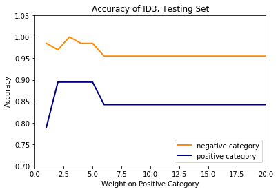

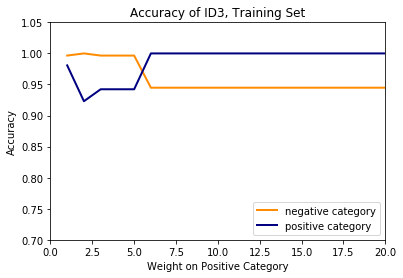

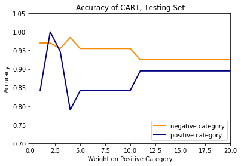

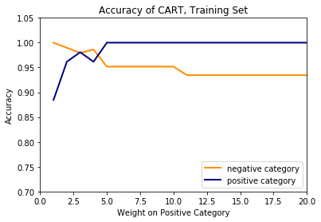

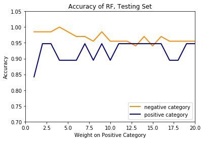

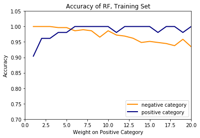

```python
def plot_accuracy(x, y, z, title = ''):
    plt.figure()
    lw = 2
    plt.plot(x, y, color='darkorange',
             lw=lw, label='negative category')
    plt.plot(x, z, color='navy',
             lw=lw, label='positive category')
    plt.xlim([0.0, 20])
    plt.ylim([0.7, 1.05])
    plt.xlabel('Weight on Positive Category')
    plt.ylabel('Accuracy')
    plt.title('Accuracy of {}'.format(title))
    plt.legend(loc="lower right")
    plt.show()

x = accuracy_ID3['weight']
y = accuracy_ID3['negative_testing']
z = accuracy_ID3['positive_testing']
plot_accuracy(x, y, z, title = 'ID3, Testing Set')

x = accuracy_ID3['weight']
y = accuracy_ID3['negative_training']
z = accuracy_ID3['positive_training']
plot_accuracy(x, y, z, title = 'ID3, Training Set')

x = accuracy_CART['weight']
y = accuracy_CART['negative_testing']
z = accuracy_CART['positive_testing']
plot_accuracy(x, y, z, title = 'CART, Testing Set')

x = accuracy_CART['weight']
y = accuracy_CART['negative_training']
z = accuracy_CART['positive_training']
plot_accuracy(x, y, z, title = 'CART, Training Set')

x = accuracy_RF['weight']
y = accuracy_RF['negative_testing']
z = accuracy_RF['positive_testing']
plot_accuracy(x, y, z, title = 'RF, Testing Set')

x = accuracy_RF['weight']
y = accuracy_RF['negative_training']
z = accuracy_RF['positive_training']
plot_accuracy(x, y, z, title = 'RF, Training Set')
```